# Finalproject: colonial transformation

# Import of packages

In order to work with my data in R, I need to install two packages; the tidyverse and the readxl, which is done by using the library function.

```r
library(tidyverse)
library(readxl)
```

# Import of data

The data used in the project is from Harvard Dataverse and is a research project that measures the impacts of colonialism in Africa and Asia. The dataset can be found by following this link: https://dataverse.harvard.edu/dataset.xhtml?persistentId=doi:10.7910/DVN/UQZFYA. I have imported the data, which is a spreadsheet in this case by using the <- function and named the spreadsheet col_transfor which is short for the original spreadsheet name “Copy of Colonial_transformation_data.xls”.

```r
col_transfor <- read_excel("Copy of Colonial_transformation_data.xls")
```

# Analysis

The following codes are a part of my analysis which will lead me to answer my research question. The analysis will contain functions that cleans the spreadsheet, functions that arrange the data and visualization. Further detailed explanations of the codes will appear in the report that goes with this project.

## Clean spreadsheet

In the column “main colonial motherland” x’s appears, which will be disturbing for my visualization later in the analysis. Therefore i use the code filter to filter out all the x’s. This creates a new dataset in the R environment which i named “cleaned_colonies”.

```r
cleaned_colonies <-col_transfor %>%
  filter(`Main colonial motherland`!= "x")
cleaned_colonies
```

```
## # A tibble: 76 x 29
##    `Country Code W… `Country Name` `Main colonial … `onset of colon…
##    <chr>            <chr>          <chr>                       <dbl>
##  1 AGO              Angola         P                            1506
##  2 ARE              Unit. Arab. E… UK                           1850
##  3 BDI              Burundi        B                            1897
##  4 BEN              Benin          F                            1878
##  5 BFA              Burkina Faso   F                            1896
##  6 BGD              Bangladesh     UK                           1757
##  7 BHR              Bahrain        UK                           1860
##  8 BRN              Brunei         UK                           1888
##  9 BWA              Botswana       UK                           1885
## 10 CAF              Central Afric… F                            1890
## # … with 66 more rows, and 25 more variables: `end of colonialism, source:
## #   Ziltener/KŸnzler 2008` <dbl>, COLYEARS <dbl>, `Violent Colonization, Wars
## #   of Defence etc; Source: own coding; cf. COW Dataset (` <dbl>, `Violent
## #   Resistence, Revolts etc.; Source: own coding; cf. COW Dataset
## #   (0=non-V;` <dbl>, `Violent Independence; Source: own coding; cf. COW
## #   Dataset (0=non-V; 1=violence;` <dbl>, `colonial violence total` <dbl>,
## #   `Form of Colonial Domination (0, 1, 2, 3, 4,)` <dbl>, `Colonial
## #   administration historically first central adminstration (0=no;
## #   1=yes)` <dbl>, `ethnic function groups used by colonial power (0=no,
## #   1=little, 2=extensive)` <dbl>, `power transfer during decolonization
## #   (0=long-term, planned, coordinated; 1=short` <dbl>, `colonial foreign trade
## #   policy: 0=not appl., 1=open door, 2=preferential tariffs,` <dbl>, `colonial
## #   trade concentration (source: Mitchell 2007; completed)` <dbl>, `colonial
## #   investment concentration (source: Kentor/Boswell 2003, completed)` <dbl>,
## #   `colonial investment in infrastructure (railways, roads, bridges, ports,
## #   irrigati` <dbl>, `plantations during colonial period: 0=no, 1=little,
## #   2=extensive` <dbl>, `gold/silver mining during colonial period: 0=no,
## #   1=little, 2=extensive` <dbl>, `mining during colonial period: 0=no,
## #   1=little, 2=extensive` <dbl>, `foreign presence (colonial countries) during
## #   colonial period; 0=<1%, 1=1-2%, 2=2` <dbl>, `immigration of foreign workers
## #   during colonial period: 0=no, 1=little, 2=extensi` <dbl>, `missionary
## #   activities during colonial period: 0=no/not appl., 1=, 2=, 3=, 4=)` <dbl>,
## #   `colonial borders split ethnic groups, cut traditional space of close
## #   interaction` <dbl>, `level of political transformation (0-100)` <dbl>,
## #   `level of economic transformation (0-100)` <dbl>, `level of social
## #   transformation (0-100)` <dbl>, `level of colonial transformation
## #   (0-100)` <dbl>
```

## Arrange data with the countries that was colonized for the longest time

I wanted to see the countries listed in order of how many years they were a colony. Therefore i use the code arrange and desc which stands for descending order and implemented it on the column COLYEARS.

```r
col_transfor %>%
  arrange(desc(COLYEARS)) %>%
  select(`Country Name`, COLYEARS, everything())
```

```
## # A tibble: 86 x 29
##    `Country Name` COLYEARS `Country Code W… `Main colonial … `onset of colon…
##    <chr>             <dbl> <chr>            <chr>                       <dbl>
##  1 Angola              469 AGO              P                            1506
##  2 Malaysia            452 MYS              UK                           1511
##  3 Mozambique          406 MOZ              P                            1569
##  4 Philippines         381 PHL              US                           1565
##  5 Sri Lanka           351 LKA              UK                           1597
##  6 Indonesia           343 IDN              NL                           1619
##  7 South Africa        342 ZAF              UK                           1652
##  8 Taiwan              321 TWN              JP                           1624
##  9 Gambia, The         304 GMB              UK                           1661
## 10 Bangladesh          190 BGD              UK                           1757
## # … with 76 more rows, and 24 more variables: `end of colonialism, source:
## #   Ziltener/KŸnzler 2008` <dbl>, `Violent Colonization, Wars of Defence etc;
## #   Source: own coding; cf. COW Dataset (` <dbl>, `Violent Resistence, Revolts
## #   etc.; Source: own coding; cf. COW Dataset (0=non-V;` <dbl>, `Violent
## #   Independence; Source: own coding; cf. COW Dataset (0=non-V;
## #   1=violence;` <dbl>, `colonial violence total` <dbl>, `Form of Colonial
## #   Domination (0, 1, 2, 3, 4,)` <dbl>, `Colonial administration historically
## #   first central adminstration (0=no; 1=yes)` <dbl>, `ethnic function groups
## #   used by colonial power (0=no, 1=little, 2=extensive)` <dbl>, `power
## #   transfer during decolonization (0=long-term, planned, coordinated;
## #   1=short` <dbl>, `colonial foreign trade policy: 0=not appl., 1=open door,
## #   2=preferential tariffs,` <dbl>, `colonial trade concentration (source:
## #   Mitchell 2007; completed)` <dbl>, `colonial investment concentration
## #   (source: Kentor/Boswell 2003, completed)` <dbl>, `colonial investment in
## #   infrastructure (railways, roads, bridges, ports, irrigati` <dbl>,
## #   `plantations during colonial period: 0=no, 1=little, 2=extensive` <dbl>,
## #   `gold/silver mining during colonial period: 0=no, 1=little,
## #   2=extensive` <dbl>, `mining during colonial period: 0=no, 1=little,
## #   2=extensive` <dbl>, `foreign presence (colonial countries) during colonial
## #   period; 0=<1%, 1=1-2%, 2=2` <dbl>, `immigration of foreign workers during
## #   colonial period: 0=no, 1=little, 2=extensi` <dbl>, `missionary activities
## #   during colonial period: 0=no/not appl., 1=, 2=, 3=, 4=)` <dbl>, `colonial
## #   borders split ethnic groups, cut traditional space of close
## #   interaction` <dbl>, `level of political transformation (0-100)` <dbl>,
## #   `level of economic transformation (0-100)` <dbl>, `level of social
## #   transformation (0-100)` <dbl>, `level of colonial transformation
## #   (0-100)` <dbl>
```

### Visualization of the colonies that was colonialized for the longest time

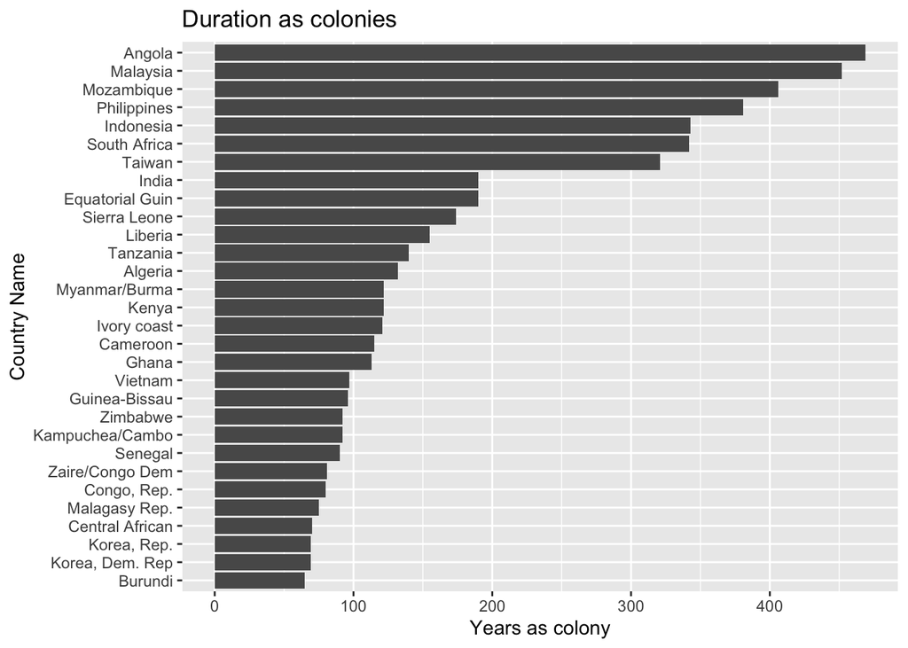

```r
col_transfor %>%
  arrange(desc(COLYEARS)) %>%
  top_n(30)%>%
  mutate(`Country Name` = reorder(`Country Name`, COLYEARS)) %>%
  ggplot(aes(x = `Country Name`, y = COLYEARS)) +
  geom_col() +
  xlab(NULL) +
  coord_flip() +
      labs(x = "Country Name",
      y = "Years as colony",
      title = "Duration as colonies")
```

## Visualization of which countries owned the most colonies

Now I wished to see which colonial powers owned the most colonies. In order to see that, i use a visualization called ggplot and implement it on the collumn named “Main colonial motherland”, and asked R to show me this visualization i bars using the geom_bar function.

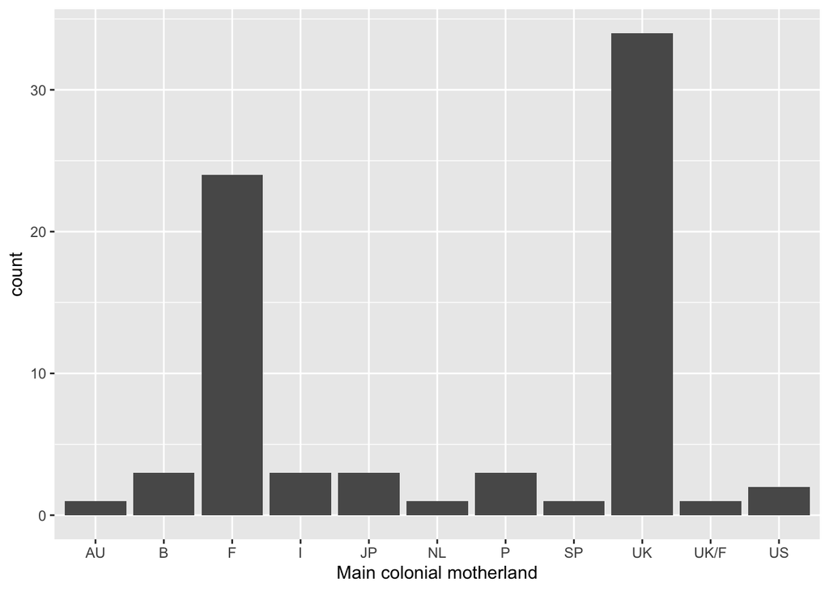

```r
cleaned_colonies %>%
  ggplot(aes(x = `Main colonial motherland`))+
  geom_bar()
```

## Economic transformation

In the following code blocks I have focused on the economic transformation that appeared in the years of the colonization. First I wanted to see the countries listed in order of the level of economic transformation they have experienced during colonization. Again I have used the arrange and desc function and implemented on the collumn "level of economic transformation (0-100).

```r
col_transfor %>%
  arrange(desc(`level of economic transformation (0-100)`)) %>%
  select(`Country Name`, `level of economic transformation (0-100)`, everything())
```

```
## # A tibble: 86 x 29
##    `Country Name` `level of econo… `Country Code W… `Main colonial …
##    <chr>                     <dbl> <chr>            <chr>
##  1 Philippines                 100 PHL              US
##  2 Fiji                         89 FJI              UK
##  3 Algeria                      86 DZA              F
##  4 Korea, Rep.                  86 KOR              JP
##  5 Korea, Dem. R…               86 PRK              JP
##  6 South Africa                 86 ZAF              UK
##  7 Zimbabwe                     86 ZWE              UK
##  8 Cameroon                     82 CMR              F
##  9 Indonesia                    82 IDN              NL
## 10 Kenya                        82 KEN              UK
## # … with 76 more rows, and 25 more variables: `onset of colonialism, source:
## #   Ziltener/KŸnzler 2008` <dbl>, `end of colonialism, source: Ziltener/KŸnzler
## #   2008` <dbl>, COLYEARS <dbl>, `Violent Colonization, Wars of Defence etc;
## #   Source: own coding; cf. COW Dataset (` <dbl>, `Violent Resistence, Revolts
## #   etc.; Source: own coding; cf. COW Dataset (0=non-V;` <dbl>, `Violent
## #   Independence; Source: own coding; cf. COW Dataset (0=non-V;
## #   1=violence;` <dbl>, `colonial violence total` <dbl>, `Form of Colonial
## #   Domination (0, 1, 2, 3, 4,)` <dbl>, `Colonial administration historically
## #   first central adminstration (0=no; 1=yes)` <dbl>, `ethnic function groups
## #   used by colonial power (0=no, 1=little, 2=extensive)` <dbl>, `power
## #   transfer during decolonization (0=long-term, planned, coordinated;
## #   1=short` <dbl>, `colonial foreign trade policy: 0=not appl., 1=open door,
## #   2=preferential tariffs,` <dbl>, `colonial trade concentration (source:
## #   Mitchell 2007; completed)` <dbl>, `colonial investment concentration
## #   (source: Kentor/Boswell 2003, completed)` <dbl>, `colonial investment in
## #   infrastructure (railways, roads, bridges, ports, irrigati` <dbl>,
## #   `plantations during colonial period: 0=no, 1=little, 2=extensive` <dbl>,
## #   `gold/silver mining during colonial period: 0=no, 1=little,
## #   2=extensive` <dbl>, `mining during colonial period: 0=no, 1=little,
## #   2=extensive` <dbl>, `foreign presence (colonial countries) during colonial
## #   period; 0=<1%, 1=1-2%, 2=2` <dbl>, `immigration of foreign workers during
## #   colonial period: 0=no, 1=little, 2=extensi` <dbl>, `missionary activities
## #   during colonial period: 0=no/not appl., 1=, 2=, 3=, 4=)` <dbl>, `colonial
## #   borders split ethnic groups, cut traditional space of close
## #   interaction` <dbl>, `level of political transformation (0-100)` <dbl>,
## #   `level of social transformation (0-100)` <dbl>, `level of colonial
## #   transformation (0-100)` <dbl>
```

### Visualization of economic transformation

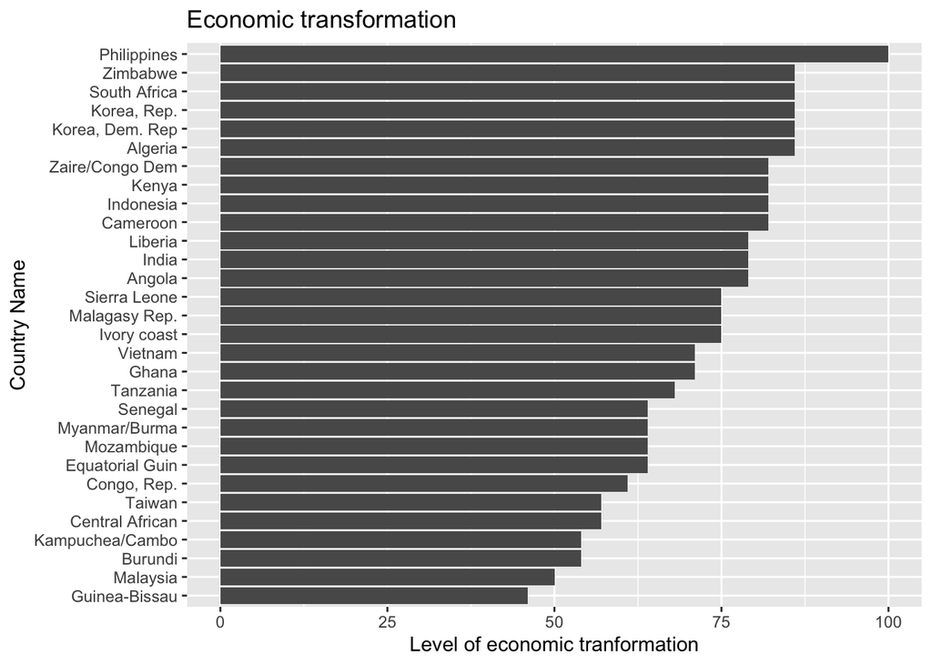

```r
col_transfor %>%
  arrange(desc(`level of economic transformation (0-100)`))%>%
  top_n(30)%>%
  mutate(`Country Name`= reorder(`Country Name`, `level of economic transformation (0-100)`))%>%
  ggplot(aes(x = `Country Name`, y = `level of economic transformation (0-100)`)) +
  geom_col() +
  xlab(NULL) +
  coord_flip() +
      labs(x = "Country Name",
      y = "Level of economic tranformation",
      title = "Economic transformation")
```

### Economic transformation by motherlands

Now I have focused on which colonial powers that managed to achieve the highest level of economic transformation in their colonies. For this purpose I have now used the cleaned_colonies data which I made in beginning of this script. Furthermore I needed to ask R to do a little math for me in order to first count how many countries each colonial power owned, and then figure out the average level of economic transformations the countries of each colonial power experienced.

In this code I have used the function count and implemented it on the column “main colonial motherland” and created new data in the environment named total_colonies.

```r
cleaned_colonies%>%
  count(`Main colonial motherland`) -> total_colonies
```

The following code leads me to the average level of economic transformation each colonial power manages to implement in their colonies. These measures ends up in a new data in the envirorment named eco_trans_motherland. The full description of the code appears in the report.

```r
cleaned_colonies%>%
  drop_na(`level of economic transformation (0-100)`)%>%
  group_by(`Main colonial motherland`)%>%
  summarise(total = sum(`level of economic transformation (0-100)`))%>%
  ungroup ()%>%
  left_join(total_colonies, by = "Main colonial motherland")%>%
  mutate(average_eco_trans = total/n)%>%
  arrange(desc(average_eco_trans)) -> eco_trans_motherland
eco_trans_motherland
```

```
## # A tibble: 11 x 4
##    `Main colonial motherland` total     n average_eco_trans
##    <chr>                      <dbl> <int>             <dbl>
##  1 US                           179     2              89.5
##  2 NL                            82     1              82
##  3 JP                           229     3              76.3
##  4 AU                            71     1              71
##  5 SP                            64     1              64
##  6 P                            189     3              63
##  7 B                            175     3              58.3
##  8 F                           1328    24              55.3
##  9 I                            143     3              47.7
## 10 UK/F                          46     1              46
## 11 UK                          1546    34              45.5
```

### Visualization of economic transformation by motherlands

The last code will show a visualization of what I just figured out above. For this visualization I have used the function geom_col which makes the height of the bars represent calues in the data.

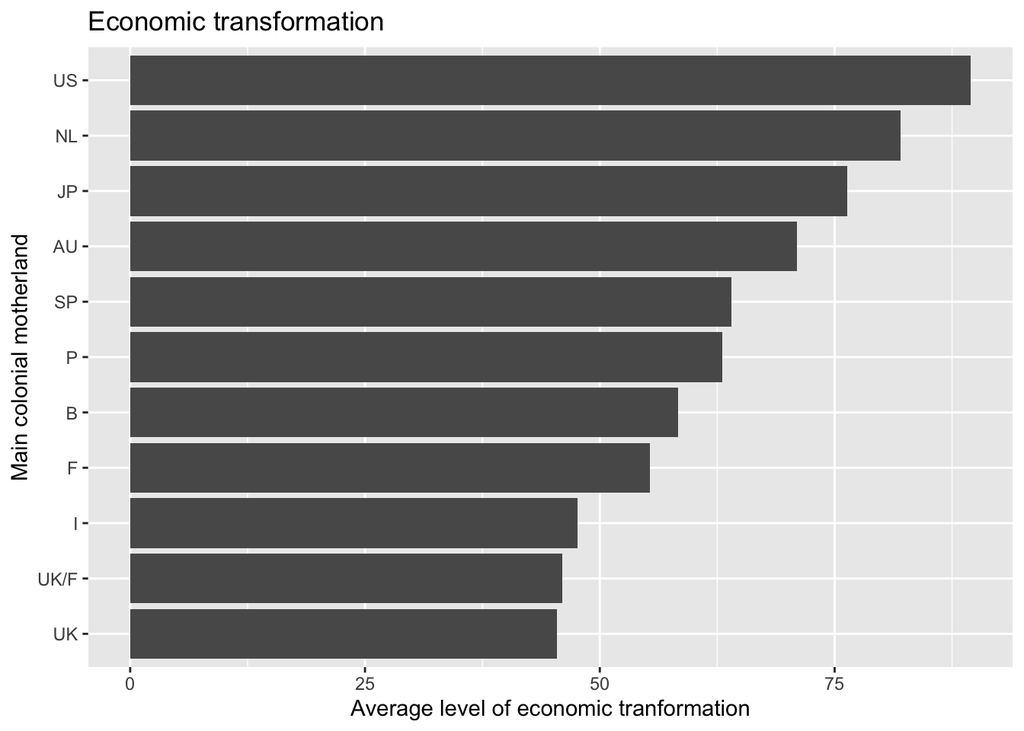

```r
eco_trans_motherland%>%
  mutate(`Main colonial motherland` = reorder(`Main colonial motherland`, average_eco_trans))%>%
  ggplot(aes(x = `Main colonial motherland`, y = average_eco_trans)) +
  geom_col() +
  coord_flip() +
      labs(x = "Main colonial motherland",
      y = "Average level of economic tranformation",
      title = "Economic transformation")
```